# Retail Store Sales Analytics Report

- Show All Code
- Hide All Code
- View Source

Author

Kousthubhee Krishna Kotte

Published

March 2, 2025

## Introduction

The Retail Store Sales dataset contains **12,575 rows** and **11 columns** of data representing sales transactions from a retail store. The dataset includes eight product categories with 25 items per category, each having static prices.

In the highly competitive retail industry, businesses rely on data analytics to optimize inventory, maximize sales, and improve customer engagement and customer satisfaction. The retail store faces challenges such as overstocking, understocking, and inefficient resource allocation, which can lead to lost sales and increased operational costs. The analysis of sales data is required to address these challenges.

This report explores sales data from retail stores, applying business analytics techniques to uncover key insights.

## Methodology

This analysis follows a structured approach:

1. **Data Loading & Cleaning**: Importing and preparing the dataset.
2. **Exploratory Data Analysis (EDA)**: Understanding sales trends and customer behavior.
3. **Business Analytics Techniques**: Applying statistical methods for decision-making.
4. **Visualizations**: Presenting key insights through graphs.
5. **Cross-Language Integration**: Using Python within Quarto for additional insights.
6. **RSQLite**: Interaction with SQLite database to query and retrieve data.

#### R Package dependencies:

- readr
- dplyr
- janitor
- lubridate
- RSQLite
- gt
- ggplot2
- reshape2
- png
- reticulate

#### Python Package dependencies:

- pandas
- matplotlib

## Load the Dataset into R

```r
# Load necessary libraries
library(readr)

# Load the dataset
sales_data <- read_csv("retail_store_sales.csv")

# View the first few rows
head(sales_data)
```

```
# A tibble: 6 × 11
  `Transaction ID` `Customer ID` Category      Item    `Price Per Unit` Quantity
  <chr>            <chr>         <chr>         <chr>              <dbl>    <dbl>
1 TXN_6867343      CUST_09       Patisserie    Item_1…             18.5       10
2 TXN_3731986      CUST_22       Milk Products Item_1…             29          9
3 TXN_9303719      CUST_02       Butchers      Item_1…             21.5        2
4 TXN_9458126      CUST_06       Beverages     Item_1…             27.5        9
5 TXN_4575373      CUST_05       Food          Item_6…             12.5        7
6 TXN_7482416      CUST_09       Patisserie    <NA>                NA         10
# ℹ 5 more variables: `Total Spent` <dbl>, `Payment Method` <chr>,
#   Location <chr>, `Transaction Date` <date>, `Discount Applied` <lgl>
```

## Data Cleaning

```r
library(dplyr)
library(janitor)
sales_data <- sales_data |>
  clean_names()

# Remove empty columns and rows
sales_data <- sales_data |>
  remove_empty("cols") |>
  remove_empty("rows")
```

### Handling missing values

```r
# Define a function to replace NA values based on conditions
replace_na_values <- function(df) {
  df <- df |>
    mutate(
      price_per_unit = if_else(
        is.na(price_per_unit) & !is.na(total_spent) & !is.na(quantity),
        total_spent / quantity,
        price_per_unit
      ),
      total_spent = if_else(
        is.na(total_spent) & !is.na(price_per_unit) & !is.na(quantity),
        price_per_unit * quantity,
        total_spent
      ),
      quantity = if_else(
        is.na(quantity) & !is.na(total_spent) & !is.na(price_per_unit),
        total_spent / price_per_unit,
        quantity
      )
    )

  # Replace with 0 when any 2 of the three columns are NA
  df <- df |>
    mutate(
      price_per_unit = if_else(is.na(price_per_unit) & (is.na(total_spent) | is.na(quantity)), 0, price_per_unit),
      total_spent = if_else(is.na(total_spent) & (is.na(price_per_unit) | is.na(quantity)), 0, total_spent),
      quantity = if_else(is.na(quantity) & (is.na(total_spent) | is.na(price_per_unit)), 0, quantity)
    )
  return(df)
}

# Apply the function to replace NA values
sales_data <- replace_na_values(sales_data)


# Replace NA values in numeric columns with 0 and in character columns with "Unknown"
sales_data <- sales_data |>
  mutate(across(where(is.numeric), ~if_else(is.na(.), 0, .))) |>
  mutate(across(where(is.character), ~if_else(is.na(.), "Unknown", .))) |>
  mutate(discount_applied = ifelse(is.na(discount_applied), FALSE, discount_applied))

colSums(is.na(sales_data))
```

```
  transaction_id      customer_id         category             item
               0                0                0                0
  price_per_unit         quantity      total_spent   payment_method
               0                0                0                0
        location transaction_date discount_applied
               0                0                0
```

### Handling duplicate records

```r
# Remove duplicate rows
sales_data <- sales_data[!duplicated(sales_data), ]

sum(duplicated(sales_data))
```

```
[1] 0
```

### Handling date format

```r
# Convert dates to Date type if applicable
library(lubridate)

sales_data$transaction_date <- as.Date(sales_data$transaction_date, format="%Y-%m-%d")

glimpse(sales_data)
```

```
Rows: 12,575
Columns: 11
$ transaction_id   <chr> "TXN_6867343", "TXN_3731986", "TXN_9303719", "TXN_945…
$ customer_id      <chr> "CUST_09", "CUST_22", "CUST_02", "CUST_06", "CUST_05"…
$ category         <chr> "Patisserie", "Milk Products", "Butchers", "Beverages…
$ item             <chr> "Item_10_PAT", "Item_17_MILK", "Item_12_BUT", "Item_1…
$ price_per_unit   <dbl> 18.5, 29.0, 21.5, 27.5, 12.5, 20.0, 5.0, 33.5, 27.5, …
$ quantity         <dbl> 10, 9, 2, 9, 7, 10, 8, 0, 1, 3, 9, 8, 7, 6, 2, 0, 8, …
$ total_spent      <dbl> 185.0, 261.0, 43.0, 247.5, 87.5, 200.0, 40.0, 0.0, 27…
$ payment_method   <chr> "Digital Wallet", "Digital Wallet", "Credit Card", "C…
$ location         <chr> "Online", "Online", "Online", "Online", "Online", "On…
$ transaction_date <date> 2024-04-08, 2023-07-23, 2022-10-05, 2022-05-07, 2022…
$ discount_applied <lgl> TRUE, TRUE, FALSE, FALSE, FALSE, FALSE, TRUE, TRUE, F…
```

## Exploratory Data Analysis (EDA)

### Summary Statistics

Summary statistics provide the concise overview of the dataset, to understand the central tendencies, variability, and overall distribution of the data.

1. Metrics like the average (mean) and median price give insights into the typical price point of products sold.
2. The average quantity sold provides an idea of how many units are typically sold per transaction.
3. Total revenue gives a clear picture of the overall financial performance of the store.
4. By comparing the mean and median, we can detect skewness in the data, which might indicate outliers or specific trends.

```r
library(gt)


# Generate summary statistics
summary_table <- sales_data |>
  summarise(
    Avg_Price = mean(price_per_unit, na.rm = TRUE),
    Median_Price = median(price_per_unit, na.rm = TRUE),
    Avg_Quantity = mean(quantity, na.rm = TRUE),
    Total_Revenue = sum(total_spent, na.rm = TRUE)
  ) |>
  gt() |>
  tab_header(
    title = "Summary of Sales Data",
    subtitle = "Key Metrics for Retail Store Sales"
  ) |>
  fmt_number(columns = everything(), decimals = 2)

summary_table
```

Summary of Sales Data

Key Metrics for Retail Store Sales

| Avg_Price | Median_Price | Avg_Quantity | Total_Revenue |
| --- | --- | --- | --- |
| 23.37 | 23.00 | 5.27 | 1,552,071.00 |

### Correlation Analysis

Correlation analysis is used to evaluate the strength and direction of the relationship between variables. In the context of retail store data, it helps identify how different factors (e.g., price, quantity, and total spending) influence each other.

```r
correlation_matrix <- select(sales_data, where(is.numeric)) |> cor(use = "complete.obs")
correlation_matrix
```

```
               price_per_unit   quantity total_spent
price_per_unit     1.00000000 0.00793059   0.5879724
quantity           0.00793059 1.00000000   0.7400788
total_spent        0.58797237 0.74007881   1.0000000
```

The correlation matrix provided reveals the relationships between **price per unit**, **quantity sold**, and **total spent** by customers.

1. **Price per Unit vs. Quantity Sold**

- **Correlation Coefficient**: **0.0079**
- **Interpretation**: The correlation between price per unit and quantity sold is **very weak (close to 0)**. This suggests that changes in the price of products have almost no impact on the quantity sold.
- **Insight**: Customers are not highly sensitive to price changes when deciding how many units to purchase. This could indicate that the store’s products are either essential items or that customers prioritize factors other than price (e.g., brand loyalty, product quality).

2. **Price per Unit vs. Total Spent**

- **Correlation Coefficient**: **0.5880**
- **Interpretation**: There is a **moderate positive correlation** between price per unit and total spent. This means that as the price per unit increases, the total amount spent by customers also tends to increase.

3. **Quantity Sold vs. Total Spent**

- **Correlation Coefficient**: **0.7401**
- **Interpretation**: There is a **strong positive correlation** between quantity sold and total spent. This indicates that customers who buy more units tend to spend more overall.

### ANOVA: Sales by different store locations

ANOVA (Analysis of Variance) is used to compare the means of two or more groups to determine if there are statistically significant differences between them. In this case, the ANOVA test was conducted to analyze whether **sales** differ significantly across **different store locations**.

```r
anova_results <- aov(total_spent ~ location, data = sales_data)
summary(anova_results)
```

```
               Df    Sum Sq Mean Sq F value Pr(>F)
location        1     16299   16299    1.75  0.186
Residuals   12573 117112146    9315
```

**F-value and p-value**

- **F-value**: The F-value is **1.75**, which measures the ratio of the variance between groups (location) to the variance within groups (residuals). A higher F-value indicates a greater difference between groups.
- **p-value**: The p-value is **0.186**, which is greater than the common significance level of **0.05**.

The p-value of **0.186** suggests that there is **no statistically significant difference** in sales across the different store locations. In other words, the variation in sales between locations is likely due to random chance rather than any inherent differences in the locations themselves.

The **Sum of Squares** for location (16,299) is relatively small compared to the total variation (117,112,146). This indicates that the location explains only a tiny fraction of the total variability in sales.

### Chi-Square Test of Independence

Pearson’s Chi-squared test is used to determine whether there is a significant association between two categorical variables. In this case, the test was conducted to evaluate the relationship between two categorical variables.

```r
table_data <- table(sales_data$category, sales_data$payment_method)
chi_square_results <- chisq.test(table_data)
chi_square_results
```

```
    Pearson's Chi-squared test

data:  table_data
X-squared = 21.006, df = 14, p-value = 0.1015
```

- The p-value of **0.1015** is greater than the common significance level of **0.05**. This indicates that there is **no statistically significant association** between the two categorical variables being tested.
- The Chi-squared statistic (**21.006**) measures the discrepancy between the observed and expected frequencies in the contingency table. A higher value indicates a greater difference between observed and expected frequencies. However, since the p-value is not significant, this discrepancy is likely due to random variation rather than a true association.
- The degrees of freedom (**14**) are determined by the number of categories in the two variables. It reflects the number of independent pieces of information used to calculate the test statistic.

# Visualizations

## Sales Trends Over Time

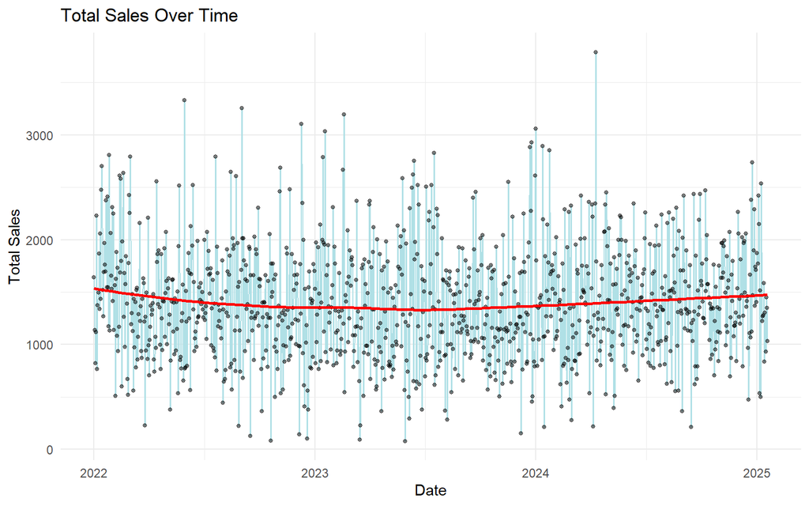

```r
library(ggplot2)

sales_data$transaction_date <- as.Date(sales_data$transaction_date)

# Aggregate sales data by date
daily_sales <- aggregate(total_spent ~ transaction_date, data = sales_data, FUN = sum)

# Create the line chart
ggplot(daily_sales, aes(x = transaction_date, y = total_spent)) +
  geom_line(group = 1, color = "powderblue") +
  geom_point(color = "black", size = 1, alpha = 0.5) +
  geom_smooth(method = "loess", se = FALSE, color = "red") +
  labs(title = "Total Sales Over Time",
       x = "Date",
       y = "Total Sales") +
  theme_minimal()
```

We observe that the store has consistent performance over the years, the peak sales being in 2024.

## Sales Distribution by Category

The bar graph represents the count of sales transactions across various product categories within the retail environment.

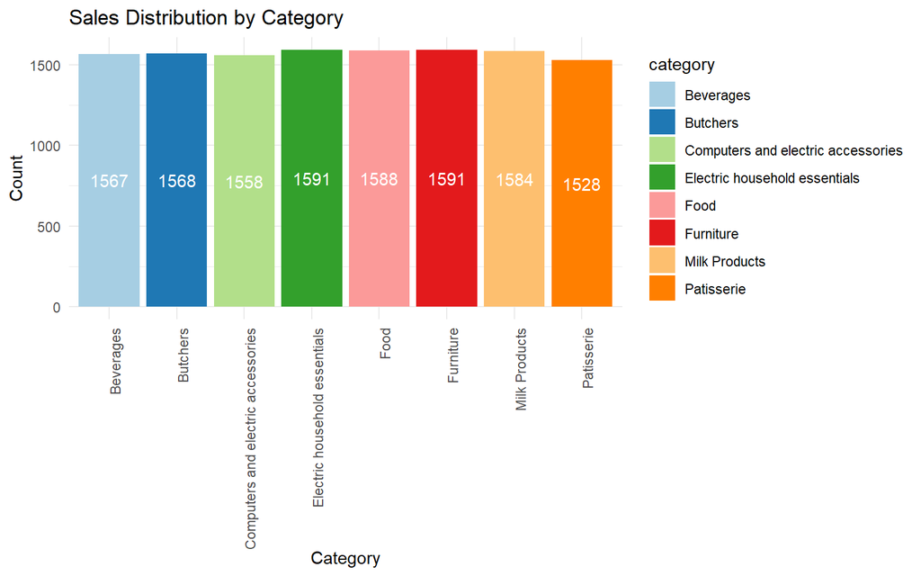

```r
ggplot(sales_data, aes(x = category, fill = category)) +
  geom_bar() +
  geom_text(stat='count', aes(label=after_stat(count)), position=position_stack(vjust=0.5), color="white") +
  scale_fill_brewer(palette = "Paired") +
  labs(title = "Sales Distribution by Category", x = "Category", y = "Count") +
  theme_minimal() +
  theme(axis.text.x = element_text(angle = 90, hjust = 1, vjust = 1))
```

The graph shows a relatively even distribution of sales across the categories, suggesting a diverse product demand within the store. No single category dominates, indicating that the store serves a wide range of consumer needs.

- **Inventory and Marketing Focus:** The store might consider increasing marketing efforts or promotions for high-performing categories to maximize revenue, while also finding ways to elevate the lower-performing categories through strategic placement, discounts, or cross-promotions.
- **Product Placement:** Optimizing store layout by placing higher-selling categories in more accessible locations could potentially increase overall sales and customer satisfaction.
- **Customer Engagement:** Special events, tastings, or showcases could be used to boost interest in lower-performing categories, potentially increasing their sales.

## Price Per Unit by Category

The boxplot displays the distribution of prices within various product categories in a store. Each boxplot shows the interquartile range (IQR) of prices within a category, with the central line representing the median price. The whiskers extending from the boxes show the typical range of prices, excluding outliers.

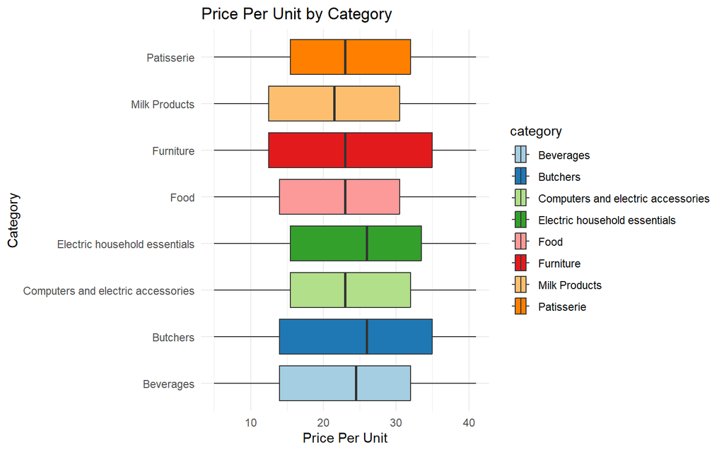

```r
library(ggplot2)

# Transposed Boxplot with Categories on the Y-axis and Prices on the X-axis
ggplot(sales_data, aes(y = category, x = price_per_unit, fill = category)) +
  geom_boxplot() +
  scale_fill_brewer(palette = "Paired") +
  labs(title = "Price Per Unit by Category", y = "Category", x = "Price Per Unit") +
  theme_minimal()
```

Categories like “Furniture” and “Butchers” show a wider IQR, indicating significant variability in the prices of products within these categories. This could be due to a diverse product range within these categories that varies greatly in quality or features.

## Correlation Heatmap of Numeric Variables

The heatmap depicts the pairwise correlation coefficients among several numeric variables in your dataset: total_spent, quantity, and price_per_unit.

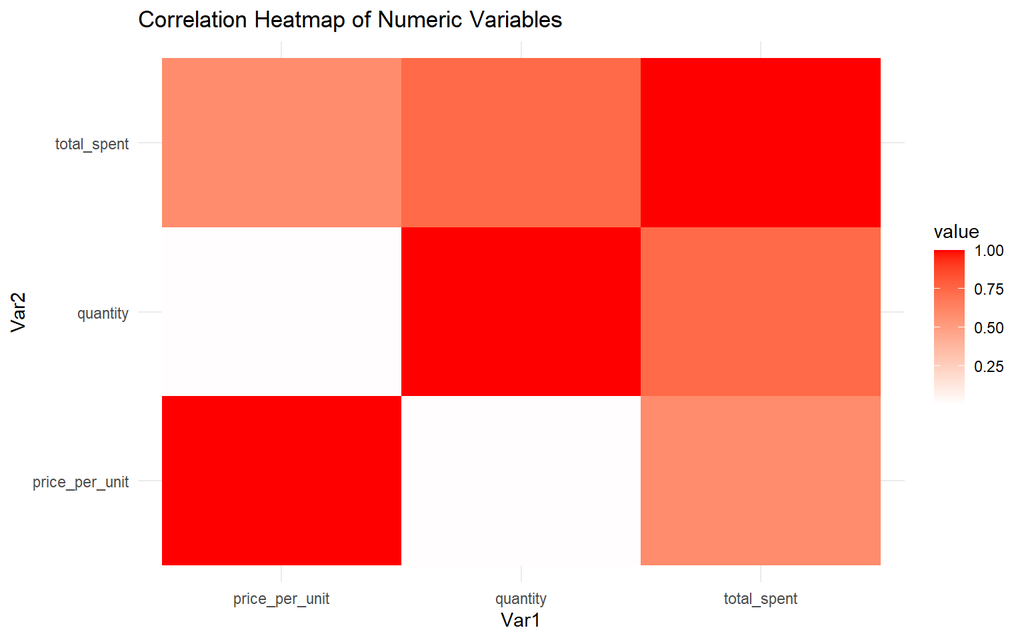

```r
library(reshape2)

cor_matrix <- sales_data |>
  select(where(is.numeric)) |>
  cor(use = "complete.obs")

melted_cor <- melt(cor_matrix)

ggplot(melted_cor, aes(x = Var1, y = Var2, fill = value)) +
  geom_tile() +
  scale_fill_gradient2(low = "blue", high = "red", mid = "white", midpoint = 0) +
  labs(title = "Correlation Heatmap of Numeric Variables") +
  theme_minimal()
```

**Strong Positive Correlation**:

## Sales Distribution in R & Python

**Note**

Python dependencies

```r
system("pip install matplotlib pandas", intern = TRUE)
```

[output not shown]

The graph represents the frequency distribution of the amount spent in transactions over a specific period. The histogram is plotted with 30 bins to provide a detailed view of how transaction values are spread.

**R**

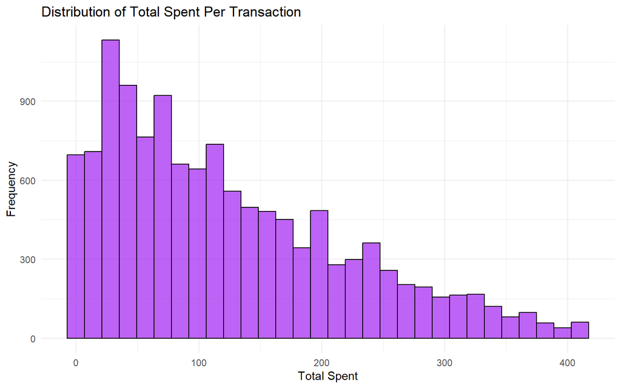

```r
sales_data |>
  ggplot(aes(x = total_spent)) +
  geom_histogram(bins = 30, fill = "purple", color = "black", alpha = 0.7) +
  labs(title = "Distribution of Total Spent Per Transaction",
       x = "Total Spent",
       y = "Frequency") +
  theme_minimal()
```

**Python**

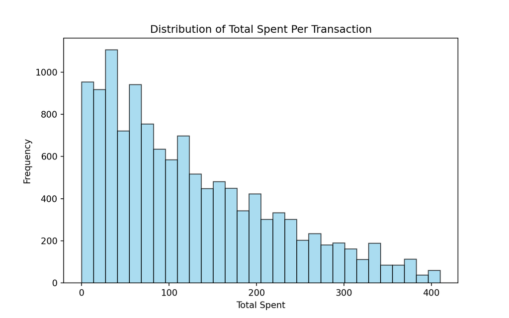

```python
import pandas as pd
import matplotlib.pyplot as plt

# Load the dataset
sales_data = r.sales_data

# Create a histogram of total_spent
plt.figure(figsize=(8,5))
plt.hist(sales_data["total_spent"], bins=30, color='skyblue', edgecolor='black', alpha=0.7)

# Add labels and title
plt.xlabel("Total Spent")
plt.ylabel("Frequency")
plt.title("Distribution of Total Spent Per Transaction")

# Show the plot
plt.show()
```

The histogram peaks around a certain range, suggesting that most transactions occur within this typical spending bracket. This central range is where the majority of customer transactions are concentrated.

The distribution appears right-skewed, indicating that while the majority of transactions are clustered around lower spending amounts, there are still a notable number of transactions that involve higher spending. This skewness towards the higher end suggests the presence of premium purchases or less frequent, high-value transactions.

- **Marketing Strategy:** Understanding the peak transaction ranges can aid in crafting targeted marketing campaigns that encourage customers to increase their spending to the next tier.
- **Customer Insight:** The distribution provides insights into customer spending habits, helping tailor customer service and product offerings to meet the prevalent spending behaviors.
- **Product Placement and Pricing:** The data suggests opportunities for strategic product placement and pricing adjustments to cater to the most common customer spending thresholds, potentially increasing overall sales effectiveness.

## RFM Analysis

RFM (Recency, Frequency, Monetary) analysis is a customer segmentation technique used in retail and marketing analytics to identify valuable customers based on their purchasing behavior. It helps businesses:

1. Identify high-value customers who contribute the most revenue.
2. Segment customers for targeted marketing campaigns.
3. Predict customer churn by analyzing engagement patterns.
4. Personalize promotions for different customer segments.

```r
compute_rfm <- function(data) {
  tryCatch({
    rfm_data <- data |>
      group_by(customer_id) |>
      summarise(Recency = as.numeric(Sys.Date() - max(transaction_date)),
                Frequency = n(),
                Monetary = sum(total_spent, na.rm = TRUE)) |>
      mutate(R_score = ntile(-Recency, 5),
             F_score = ntile(Frequency, 5),
             M_score = ntile(Monetary, 5),
             RFM_score = R_score * 100 + F_score * 10 + M_score)

    return(rfm_data)
  }, error = function(e) {
    message("Error in compute_rfm: ", e$message)
    return(NULL)
  })
}

rfm_scores <- compute_rfm(sales_data)
head(rfm_scores)
```

```
# A tibble: 6 × 8
  customer_id Recency Frequency Monetary R_score F_score M_score RFM_score
  <chr>         <dbl>     <int>    <dbl>   <int>   <int>   <int>     <dbl>
1 CUST_01          43       507   58732.       4       3       1       431
2 CUST_02          45       488   62046.       2       2       4       224
3 CUST_03          45       465   60811        2       1       2       212
4 CUST_04          43       474   61768.       4       1       3       413
5 CUST_05          47       544   66974.       1       5       5       155
6 CUST_06          45       481   58632.       2       1       1       211
```

We calculated three key metrics for each customer:

- **Recency (R)**: Days since the customer’s last purchase (lower is better).
- **Frequency (F)**: Total number of purchases made (higher is better).
- **Monetary (M)**: Total amount spent (higher is better).

The RFM score was computed by concatenating these three scores (e.g., 431 for CUST_01), allowing for segmentation into different customer categories.

**Key Takeaways from the top 6 RFM Results**

- CUST_01 (431) - Recently active but moderate frequency and low monetary value. Likely a **new but engaged** customer.
- CUST_02 (224) - Not very recent, low frequency, but high spending. A **big spender at risk of churn**.
- CUST_03 (212) - Low recency, low frequency, and moderate spending. A **low-engagement** customer who may **need reactivation**.
- CUST_04 (413) - Recent but with low frequency and moderate spending. Could be a **new high-potential** customer.
- CUST_05 (155) - Very old but high frequency and high spending. A **loyal high-value** customer who should be nurtured.
- CUST_06 (211) - Low across all metrics, indicating a **low-value or inactive** customer.

# Store Data in SQLite using RSQLite

**Create connection**

```r
# Load SQLite library
library(RSQLite)

# Create a connection to the database
conn <- dbConnect(SQLite(), "retail_store_sales.db")

# Write data to SQLite database
dbWriteTable(conn, "sales", sales_data, overwrite = TRUE, row.names = FALSE)
```

**Read the data and perform analysis**

```r
# Read data back from SQLite
retrieved_data <- dbReadTable(conn, "sales")

# SQL query to calculate total sales and average price per unit by category

query <- "
SELECT category, SUM(total_spent) AS total_sales, AVG(price_per_unit) AS average_price_per_unit
FROM sales
GROUP BY category
ORDER BY total_sales DESC
"
# Execute the query and store the results
analysis_results <- dbGetQuery(conn, query)

head(analysis_results)
```

```
                            category total_sales average_price_per_unit
1                           Butchers    208118.0               25.10746
2      Electric household essentials    203813.5               24.53771
3                          Beverages    197047.5               23.29004
4                          Furniture    195310.0               23.34224
5                               Food    194812.0               23.07557
6 Computers and electric accessories    190692.5               23.11457
```

**Close the connection**

```r
# Close connection
dbDisconnect(conn)
```

# Conclusion

The **Retail Store Sales Analytics Report** provides a comprehensive analysis of sales data to uncover key insights and inform strategic decision-making. Through a structured approach involving data cleaning, exploratory data analysis (EDA), statistical methods, and visualizations, we have gained valuable insights into sales trends, customer behavior, and product performance.

## Recommendations for strategic business decisions:

The findings and recommendations provided in this report serve as a foundation for informed decision-making and strategic planning.